# STAT-S632

Tree Models

```r
library(rpart)
library(ggplot2)
import::from(magrittr, `%>%`, `%<>%`)
library(rpart.plot)
import::from(randomForest, randomForest)

theme_set(theme_bw())
```

Before, we discussed OLS, GLS, and mixed models. These are “model based approaches”. We fored some model to be fit to the data, and then we checked to see if the data actually is an appropriate fit to such a model (diagnostics and model selection). Then we came up with some interpretations of model parameters, predictions, and estimations (model inference).

Next, we look at “algorithm-based approahces”. This involves devising some method (AKA an algorithm) that produces appropriate results. Now we don’t have model parameters to be estimated. Instead, we are only concerned with predictions. In some cases, we can obtain some interpretations based on the results, which are largely restricted to coming up with a relationship between a predictor or a group of predictors and the response.

# Regression Trees

Recusrive partitioning algorithm:

1. Consider all partitions of size 2 for each predictor. We have at most $(n - 1) p$ of them (if all $p$ predictors are continuous).
2. For each partition, take the mean of the response in that partition. Compute $RSS(partition) = RSS(part_1) + RSS(part_2)$. Choose the one that minimizes this.
3. Subpartition the partitions in a recursive manner.

Then once we obtain the final partitioning, we can say that the predicted response for each partition is the average response in that partition (and we can also obtain summary statistics for each partition).

For an ordinal predictor with $L$ levels, there are at moast $L - 1$ possible splits. For a categorical and unordered factor, there are $2^{L-1} - 1$ possible splits. We might want a strategy for limiting the number of possibilities.

We might want to treat missigness as an additional factor

```r
data(ozone, package = 'faraway')
summary(ozone)
```

```
       O3              vh            wind           humidity
 Min.   : 1.00   Min.   :5320   Min.   : 0.000   Min.   :19.00
 1st Qu.: 5.00   1st Qu.:5690   1st Qu.: 3.000   1st Qu.:47.00
 Median :10.00   Median :5760   Median : 5.000   Median :64.00
 Mean   :11.78   Mean   :5750   Mean   : 4.848   Mean   :58.13
 3rd Qu.:17.00   3rd Qu.:5830   3rd Qu.: 6.000   3rd Qu.:73.00
 Max.   :38.00   Max.   :5950   Max.   :11.000   Max.   :93.00
      temp            ibh              dpg              ibt
 Min.   :25.00   Min.   : 111.0   Min.   :-69.00   Min.   :-25.0
 1st Qu.:51.00   1st Qu.: 877.5   1st Qu.: -9.00   1st Qu.:107.0
 Median :62.00   Median :2112.5   Median : 24.00   Median :167.5
 Mean   :61.75   Mean   :2572.9   Mean   : 17.37   Mean   :161.2
 3rd Qu.:72.00   3rd Qu.:5000.0   3rd Qu.: 44.75   3rd Qu.:214.0
 Max.   :93.00   Max.   :5000.0   Max.   :107.00   Max.   :332.0
      vis             doy
 Min.   :  0.0   Min.   : 33.0
 1st Qu.: 70.0   1st Qu.:120.2
 Median :120.0   Median :205.5
 Mean   :124.5   Mean   :209.4
 3rd Qu.:150.0   3rd Qu.:301.8
 Max.   :350.0   Max.   :390.0
```

```r
tmod <- rpart(O3 ~ ., ozone)
tmod
```

```
n= 330

node), split, n, deviance, yval
      * denotes terminal node

 1) root 330 21115.4100 11.775760
   2) temp< 67.5 214  4114.3040  7.425234
     4) ibh>=3573.5 108   689.6296  5.148148 *
     5) ibh< 3573.5 106  2294.1230  9.745283
      10) dpg< -9.5 35   362.6857  6.457143 *
      11) dpg>=-9.5 71  1366.4790 11.366200
        22) ibt< 159 40   287.9000  9.050000 *
        23) ibt>=159 31   587.0968 14.354840 *
   3) temp>=67.5 116  5478.4400 19.801720
     6) ibt< 226.5 55  1276.8360 15.945450
      12) humidity< 59.5 10   167.6000 10.800000 *
      13) humidity>=59.5 45   785.6444 17.088890 *
     7) ibt>=226.5 61  2646.2620 23.278690
      14) doy>=306.5 8   398.0000 16.000000 *
      15) doy< 306.5 53  1760.4530 24.377360
        30) vis>=55 36  1149.8890 22.944440 *
        31) vis< 55 17   380.1176 27.411760 *
```

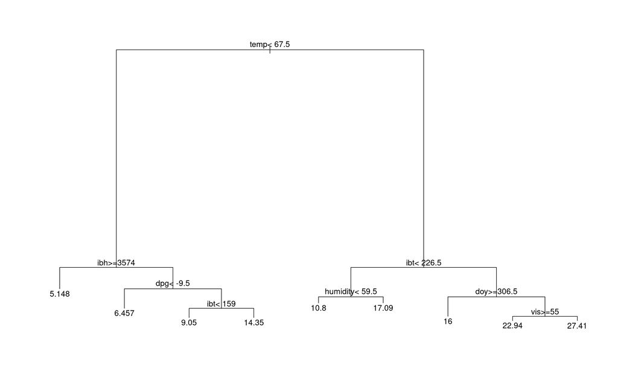

```r
plot(tmod)
text(tmod)
```

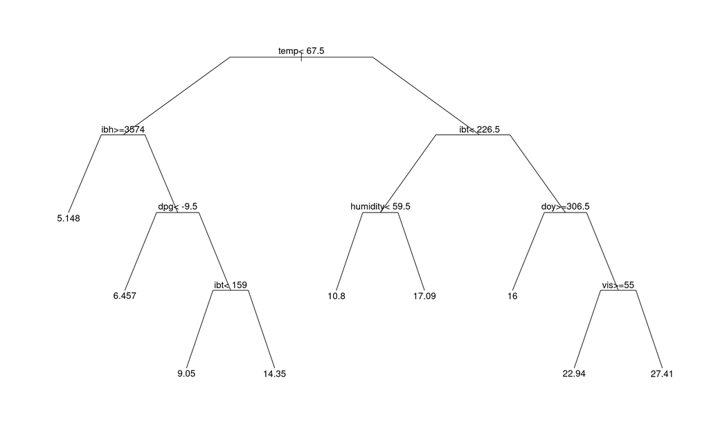

```r
plot(tmod, compress = TRUE, uniform = TRUE, branch = .4)
text(tmod)
```

In the diagrams above, if the condition at a node is met, go to the left branch, else go to the right branch.

The values at the terminal nodes are $\hat{y}$, the average responses after following the branches.

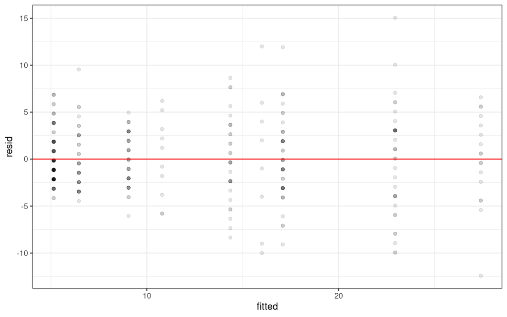

```r
ozone %>%
  dplyr::mutate(fitted = predict(tmod),
                resid = residuals(tmod)) %>%
  ggplot() +
  geom_point(aes(x = fitted, y = resid), alpha = .1) +
  geom_abline(slope = 0, colour = 'red')
```

… but we are not assuming homoscedacity. There are no model assumptions here.

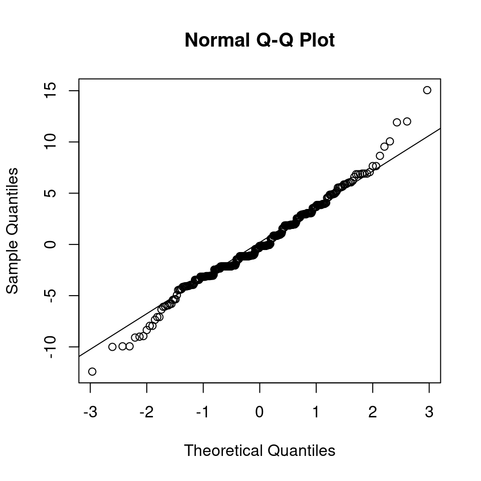

```r
qqnorm(residuals(tmod))
qqline(residuals(tmod))
```

We are also not assuming normality of the residuals.

## Tree pruning, model selection

Question: When do we stop partitioning?

In theory, we can have as many terminal nodes as we have data points, but that doesn’t tell us much about the data.

*Greedy strategy* - keep partitioning until reduction in $RSS \leq \epsilon$—how to set $\epsilon$?

Issue: RSS and deviance improve as model complexity increases—need to penalize large models

One strategy - leave-one-out CV: $\sum_j^n (y_j - f_{-j}(x_j))^2$, then do this for all possible trees and pick the one with the smallest CV RSS.

Another - $k$-fold CV

1. Randomly partition data into $k$ partitions of roughly equal size
2. For $i = 1$ to $k$, predict on the $k$<sup>th</sup> partition after fitting a model on the other $k-1$ partitions collectively.
3. Calculate RSS for the $k$<sup>th</sup> group, then sum them up to find total RSS.
4. Do this for all possible types of trees and pick the best type.

What do we mean by types of trees:

- Usually, fix a number of terminal nodes
- Tree depth

Cross validation can be expensive. Instead can try a penalized loss function $CC(Tree) = \sum_{i \in \text{terminal nodes}} RSS_i + \lambda \times (\text{# terminal nodes})$  
(cost-complexity function)

Need to choose $\lambda$ (complexity parameter)

In `rpart` package, uses $cp = \frac{\lambda}{RSS_0}$ where $RSS_0 =$ $RSS$ for entire data (root node)

```r
set.seed(123)
tmod <- rpart(O3 ~ ., data = ozone, cp = .001)
printcp(tmod)
```

```
Regression tree:
rpart(formula = O3 ~ ., data = ozone, cp = 0.001)

Variables actually used in tree construction:
[1] doy      dpg      humidity ibh      ibt      temp     vh       vis

Root node error: 21115/330 = 63.986

n= 330

          CP nsplit rel error  xerror     xstd
1  0.5456993      0   1.00000 1.00296 0.076477
2  0.0736591      1   0.45430 0.50019 0.043274
3  0.0535415      2   0.38064 0.45752 0.041780
4  0.0267557      3   0.32710 0.39790 0.038133
5  0.0232760      4   0.30034 0.41249 0.039340
6  0.0231021      5   0.27707 0.41252 0.039022
7  0.0153249      6   0.25397 0.39159 0.039024
8  0.0109137      7   0.23864 0.38880 0.038336
9  0.0070746      8   0.22773 0.36305 0.034622
10 0.0059918      9   0.22065 0.35872 0.033802
11 0.0059317     10   0.21466 0.35754 0.034008
12 0.0049709     12   0.20280 0.36274 0.035600
13 0.0047996     15   0.18789 0.36498 0.036045
14 0.0044712     16   0.18309 0.36910 0.036391
15 0.0031921     17   0.17861 0.36760 0.036586
16 0.0022152     19   0.17223 0.37110 0.037023
17 0.0020733     20   0.17002 0.37314 0.037073
18 0.0020297     22   0.16587 0.37261 0.036929
19 0.0014432     23   0.16384 0.37363 0.036966
20 0.0011322     24   0.16240 0.37209 0.037019
21 0.0011035     25   0.16126 0.37043 0.037059
22 0.0010000     26   0.16016 0.37004 0.037069
```

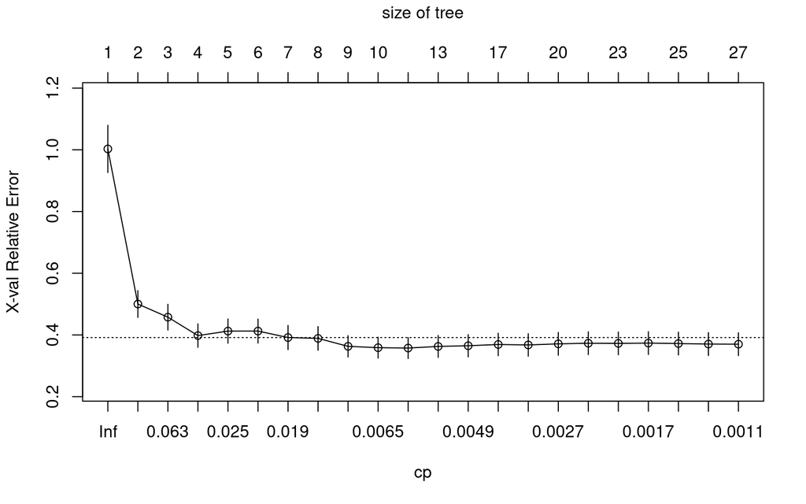

```r
plotcp(tmod)
```

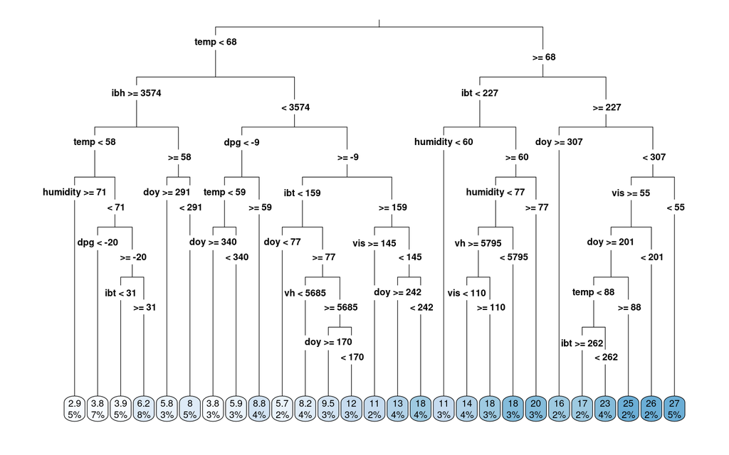

```r
rpart.plot(tmod, type = 3)
```

```r
names(tmod)
```

```
 [1] "frame"               "where"               "call"
 [4] "terms"               "cptable"             "method"
 [7] "parms"               "control"             "functions"
[10] "numresp"             "splits"              "variable.importance"
[13] "y"                   "ordered"
```

```r
tmodr <- prune.rpart(tmod, .0154)
1 - var(residuals(tmodr)) / var(ozone$O3)
```

```
[1] 0.7460337
```

```r
1 - var(residuals(tmod)) / var(ozone$O3)
```

```
[1] 0.8398401
```

## Random forests

*Bagging* - bootstrap aggregating

For $b = 1, ..., B$:

1. Draw a random sample with replacement from the data $(X, Y)$ to generate a bootstrapped sample $(X_b, Y_b)$
2. Fit a regression tree to $(X_b, Y_b)$
3. For out of bag, obtain MSE

End up with $B$ trees (a forest).

$\bar{T} =$ average of $B$ iid random variables each with variance $\sigma^2$ has variance $\frac{\sigma^2}{B}$. But if these are not independent, we get $var(\bar{T}) = \rho \sigma^2 + \frac{1 - \rho}{B} \sigma^2$

To reduce correlation among trees, do not use all variables at each node (typically $\sqrt{p}$)

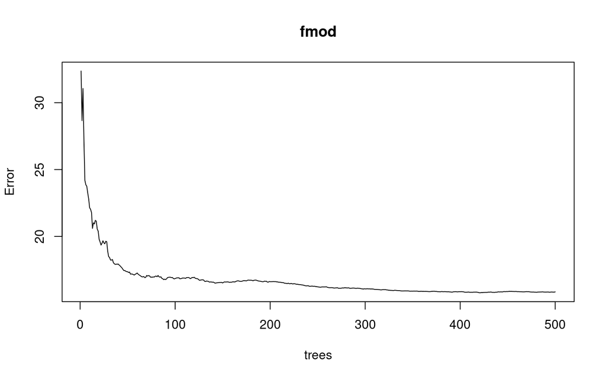

```r
fmod <- randomForest(O3 ~ ., ozone)
plot(fmod)
```